# Introduction to QualCoder

## 6.1 Include memos, or only memos

The memo drop-down (it says **None** to start) decides whether memos are in the report. There are two kinds of memo: memos on **coded text**, like the summaries you wrote today, and memos on **codes** themselves (right-click a code, **View or edit memo**), which work like a codebook to remind you what each code means.

| Choose | The report shows |
| --- | --- |
| **None** | All the coded text, no memos. |
| **Also code memos** | All the coded text, plus the memos on your codes. |
| **Also coded memos** | All the coded text, plus the memos on coded text: the summaries that give you a head start on analysis. |
| **Also all memos** | All the coded text, plus both kinds of memo. |
| **Only memos** | Both kinds of memo, and no coded text. |
| **Only coded memos** | Only the memos on coded text, and no coded text. |

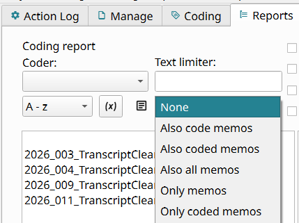

The memo options in a coding report.

**NoteIn QualCoder: add your memos to the report**

1. Keep all the transcripts and codes selected.
2. In the memo drop-down, choose **Also coded memos**.
3. Click **Play**. Your memos now appear with the text they’re attached to.

**NoteIn QualCoder: report only your memos**

1. In the memo drop-down, choose **Only coded memos**.
2. Click **Play**. The report now lists just your memos: a first draft of your analysis notes.

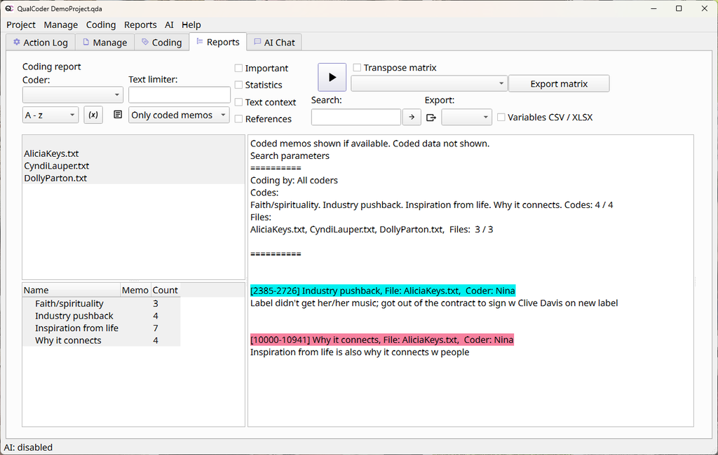

A report of only coded memos: each memo under the code and file it belongs to.

## 6.2 A codes-by-file matrix

A matrix shows which codes appear in which files: codes are columns and files are rows.

**NoteIn QualCoder: make a matrix**

1. Keep all the transcripts and codes selected, and set the memo drop-down back to **None**.
2. In the drop-down next to the **Play** button, choose **Codes by file**.
3. Click **Play**. To swap rows and columns, check **Transpose matrix**.

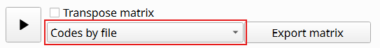

The matrix options sit next to the Play button.

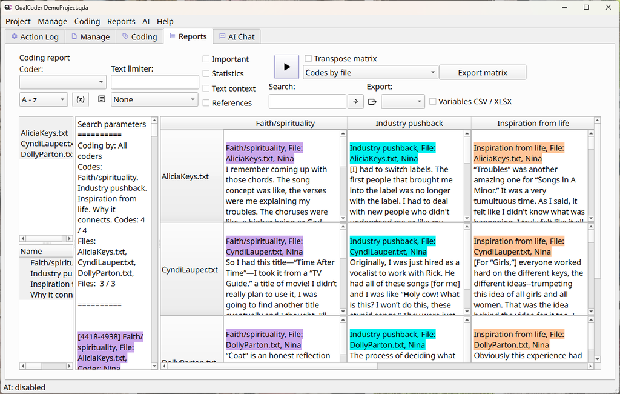

A codes-by-file matrix: one row per transcript, one column per code.

## 6.3 Try other reports

To get a different report, change what’s selected and click **Play** again.

QualCoder has many other report formats and settings. See the [QualCoder reports documentation](https://qualcoder.org/doc/en/5.3.-Reports/).

# 7 Close your project

**WarningGotcha: always close the project when you’re done**

Close the project whenever you’re done for the day. An open project is locked, so if it’s on a shared computer or a shared drive, nobody else can open it until you close it. Closing also makes sure everything is saved before you copy the folder anywhere.

## 7.1 Close the project

**Mac**

**NoteIn QualCoder: close the project**

1. Go to **Project > Close Project** (or **Option + X**).
2. Click the **Action Log** tab. It lists what changed in this session and ends with **Closing project**.

[figure not shown]

On a Mac, Close Project is in the Project menu in the menu bar.

**Windows**

**NoteIn QualCoder: close the project**

1. Go to **Project > Close Project** (or **Alt + X**).
2. Click the **Action Log** tab. It lists what changed in this session and ends with **Closing project**.

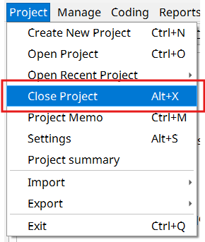

Close Project is in the Project menu.

## 7.2 Reopen the project and find your backup

QualCoder makes a backup when you open a project, so reopening it now creates your first backup in the `backups` folder.

**NoteIn QualCoder: reopen the project**

1. Go to **Project > Open Recent Project** and choose `intro-qc-workshop.qda`.
2. Click the **Action Log** tab. Look for **Project backup created**, followed by the backup’s location in `qualcoder-workshop/backups` and its name, such as `intro-qc-workshop_BKUP_20261106_10.qda` (the date and the hour).

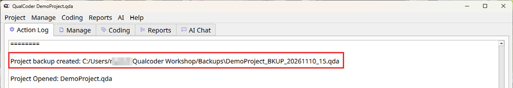

After reopening, the Action Log shows where the backup was saved.

## 7.3 Close it again and quit

**Mac**

**NoteIn QualCoder: close the project and quit**

1. Go to **Project > Close Project** (or **Option + X**).
2. Quit QualCoder: **Qualcoder > Quit Qualcoder** (or **Cmd + Q**).

**Windows**

**NoteIn QualCoder: close the project and exit**

1. Go to **Project > Close Project** (or **Alt + X**).
2. Exit QualCoder: **Project > Exit** (or **Ctrl + Q**).

# 8 QualCoder resources

NC State University Libraries Data Science Services: contact us, book an appointment, or reserve a workstation (with QualCoder installed!) at go.ncsu.edu/getdatahelp

- [QualCoder documentation](https://qualcoder.org/doc/en/): the full manual.
- [Coding text](https://qualcoder.org/doc/en/4.1.-Coding-Text/) and [Reports](https://qualcoder.org/doc/en/5.3.-Reports/) in the documentation.
- The Library of Congress [index of Recording Registry interviews](https://www.loc.gov/programs/national-recording-preservation-board/recording-registry/index-of-interviews/): more than 100 more interviews with musicians, producers and songwriters to practice on.

## References

Library of Congress. (2016, February 19). *Interview with Dolly Parton* [Interview transcript]. National Recording Preservation Board, National Recording Registry. https://www.loc.gov/static/programs/national-recording-preservation-board/documents/DollyPartonInterview.pdf

Library of Congress. (2019, May 24). *Interview with Cyndi Lauper* [Interview transcript]. National Recording Preservation Board, National Recording Registry. https://www.loc.gov/static/programs/national-recording-preservation-board/documents/CyndiLauperInterview.pdf

Library of Congress. (2022, April 13). *Interview with Alicia Keys* [Interview transcript]. National Recording Preservation Board, National Recording Registry. https://www.loc.gov/static/programs/national-recording-preservation-board/documents/Interview_Alicia-Keys.pdf

The plain-text copies used in this workshop are in the [`data` folder of this guide’s repository](https://github.com/NCSU-Libraries/intro-qualcoder/tree/main/data). Copyright is held by the authors; they are shared with permission of the Library of Congress for noncommercial scholarly and educational use only.

# Extra activities

These are in the QualCoder Quick Start guide but not in today’s session. Try them on the workshop project, or come back to them when you start your own.

## Working as a team

A QualCoder project can’t be opened by two people at once, so decide **how** you’ll work together before you create the project.

**Working one at a time (sequentially).** Only one person works on the project at any moment. Either:

- Do all the coding on one computer, used by one person at a time, or
- Code on several computers and pass the project on: close it, zip the `.qda` folder and send it to the next person.

**Working at the same time (in parallel).** Each person has their own project folder.

- The transcripts imported into each project can be exactly the same, or each person can take a share.
- Ideally, agree on the codes before you start. It’s fine if you don’t, but then documenting your codes is extra important.
- You can share project folders with each other when you want to.

Either way, agree as a team on where project files will live and how to name each person’s project folder. If the team has several deliverables, a subfolder per deliverable helps. Set a different coder name for each person (Section 3), and keep a shared list of which color goes with which code.

To see what one person coded, run a report (Section 6) and choose their name from the **Coder** drop-down at the top left of the report window.

## Open an existing project

QualCoder may open your most recent project when it starts. If it doesn’t:

**NoteIn QualCoder: open a project**

1. Click **Project > Open Project**, go to your project folder, click once on the `.qda` folder and click **Select Folder** (on a Mac, **Open**).
2. Or click **Project > Open Recent Project** and choose the project.

Each time you open QualCoder, check that you’re in the right project.

## Fix a typo in a transcript

If you spot an error in a transcript (for example, “force plan” where the speaker said “forest plan”), you can fix it in QualCoder.

**NoteIn QualCoder: edit transcript text**

1. In the Coding tab, click the **Edit Text** button. Text that’s already coded is underlined.
2. Make your changes. Keep edits small: single words, short phrases or punctuation.
3. Click **End Edit Text** when you’re done.

The change is made only in the project’s copy of the transcript; the original file isn’t changed. For anything bigger, clean the file (in Word, for example) *before* you import it.

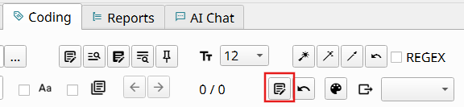

The Edit Text button in the Coding tab’s toolbar.

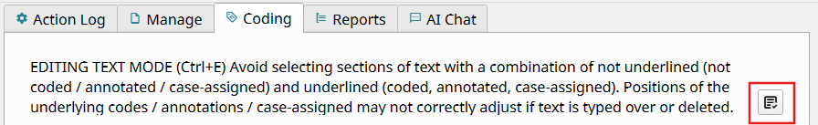

In editing mode, a note explains what to avoid. Click the same button to end editing.

## Memo a whole file

Use a file memo to track progress, such as “Coded, 10/1/26”.

**NoteIn QualCoder: add a file memo**

1. Go to **Manage > Manage Files**.
2. Click once in the **Memo** column for the file and type your memo.

## More coding shortcuts

| New code | Quick code | Recent code | Uncode |
| --- | --- | --- | --- |
| Shift + N | Shift + Q | Shift + R | Shift + U |
| **Add memo** | **Annotate** | **Mark important** | **Bookmark** |
| Shift + M | Shift + A | Shift + I | Shift + B |

- **Quick code (Shift + Q)** applies the same code you used last.
- **Shift + ←** and **Shift + →** extend coded text to the left or right. QualCoder can be slow at this; it’s often quicker to uncode and recode the passage.
- The color picker has options for color vision deficiencies.

## Code other kinds of files

QualCoder can code PDFs, images, audio and video, not just text. See [Coding text](https://qualcoder.org/doc/en/4.1.-Coding-Text/) and the rest of the [documentation](https://qualcoder.org/doc/en/).

## QualCoder’s AI features

QualCoder can work with AI tools to help search and code your data. Before you turn this on, check with your advisor and your IRB: sending research data to an AI service may not be allowed under your protocol. See the [QualCoder documentation](https://qualcoder.org/doc/en/).